# ARDL Metode Peramalan Deret Waktu

Sandra Berliana Putri

2024-10-22

## *Packages*

```r
library(dLagM)
library(dynlm)
library(MLmetrics)
library(lmtest)
library(car)
```

```r
library(ggplot2)
```

## Import Data

Data ini terdiri atas jumlah penumpang transjakarta sebagai peubah dependen (Y) dan penyesuain rute sebagai peubah independen (X) Indonesia periode Januari 2023 - Juni 2024.

```r
data <- read.csv("C:\\Users\\ASUS\\Downloads\\Data Jumlah Penumpang Transjakarta Harian Tahun 2023-2024.1 (2).csv")
data <- data[,c(-1,-4)]
data
```

```
##     jumlah_penumpang_transjakarta PenyesuaianRute
## 1                          363250               0
## 2                          730984               0
## 3                          783228               0
## 4                          798449               0
## 5                          807905               0
## 6                          807617               0
## 7                          533011               0
## 8                          462270               0
## 9                          813091               0
## 10                         813213               0
## 11                         813605               0
## 12                         814531               0
## 13                         819097               0
## 14                         535942               0
```

[output cut: 532 more lines]

```r
# Membuat kolom tanggal yang dimulai dari 1 Januari 2023 dan memiliki 546 baris
dates <- seq(from = as.Date("2023-01-01"), by = "day", length.out = 546)
dates[546]
```

```
## [1] "2024-06-29"
```

```r
# Menambahkan kolom tanggal ke dataset
data$Date <- dates

# Menampilkan data untuk memeriksa kolom baru
head(data)
```

```
##   jumlah_penumpang_transjakarta PenyesuaianRute       Date
## 1                        363250               0 2023-01-01
## 2                        730984               0 2023-01-02
## 3                        783228               0 2023-01-03
## 4                        798449               0 2023-01-04
## 5                        807905               0 2023-01-05
## 6                        807617               0 2023-01-06
```

# Eksplorasi Data

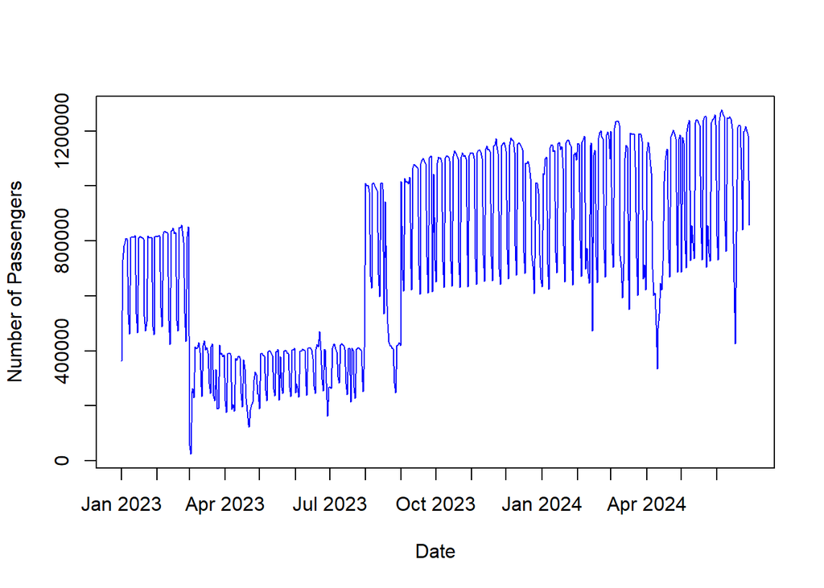

```r
# Plot time series jumlah penumpang dengan sumbu x berupa tanggal
plot(  data$Date, data$jumlah_penumpang_transjakarta, type = "l", xlab = "Date", ylab = "Number of Passengers",
     col = "blue", xaxt = "n")

# Menambahkan tanggal pada sumbu x dengan format bulan dan tahun
axis(1, at = seq(from = min(data$Date), to = max(data$Date), by = "months"),
     labels = format(seq(from = min(data$Date), to = max(data$Date), by = "months"), "%b %Y"))

# Menambahkan titik untuk data penumpang
points(data[,1], pch = 20, col = "blue")
```

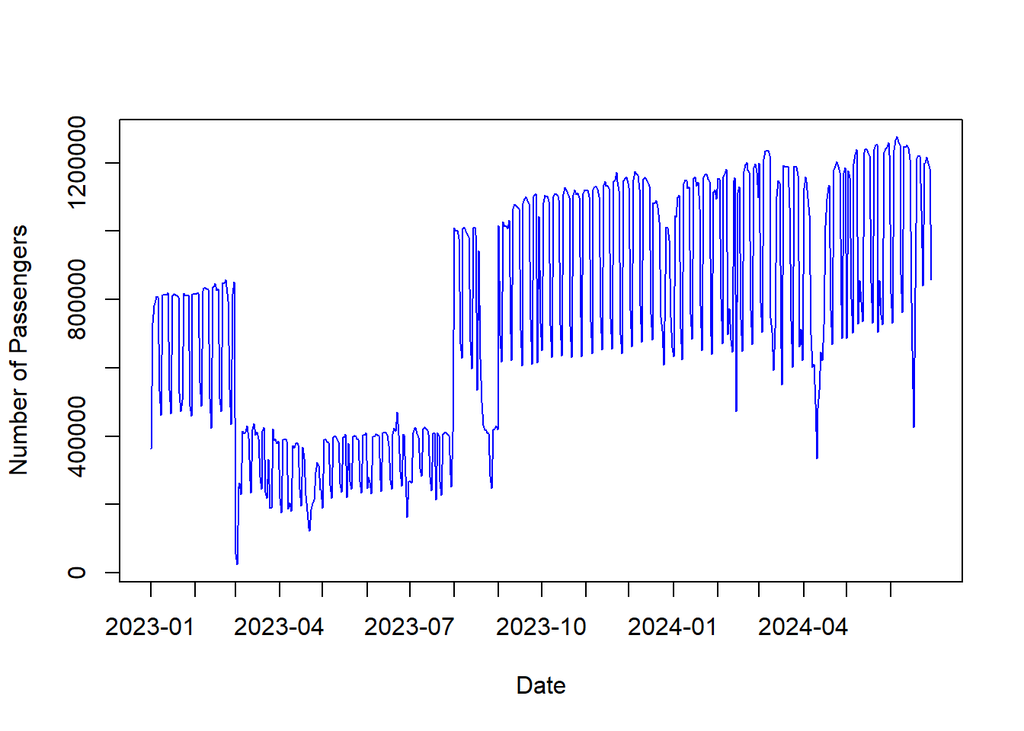

```r
# Plot time series jumlah penumpang dengan sumbu x berupa tanggal
plot(data$Date, data$jumlah_penumpang_transjakarta, type = "l", xlab = "Date", ylab = "Number of Passengers",
     col = "blue", xaxt = "n")

# Menambahkan tanggal pada sumbu x dengan format "YYYY-MM"
axis(1, at = seq(from = min(data$Date), to = max(data$Date), by = "month"),
     labels = format(seq(from = min(data$Date), to = max(data$Date), by = "month"), "%Y-%m"))

# Menambahkan titik untuk data penumpang
points(data$Date, pch = 20, col = "blue")
```

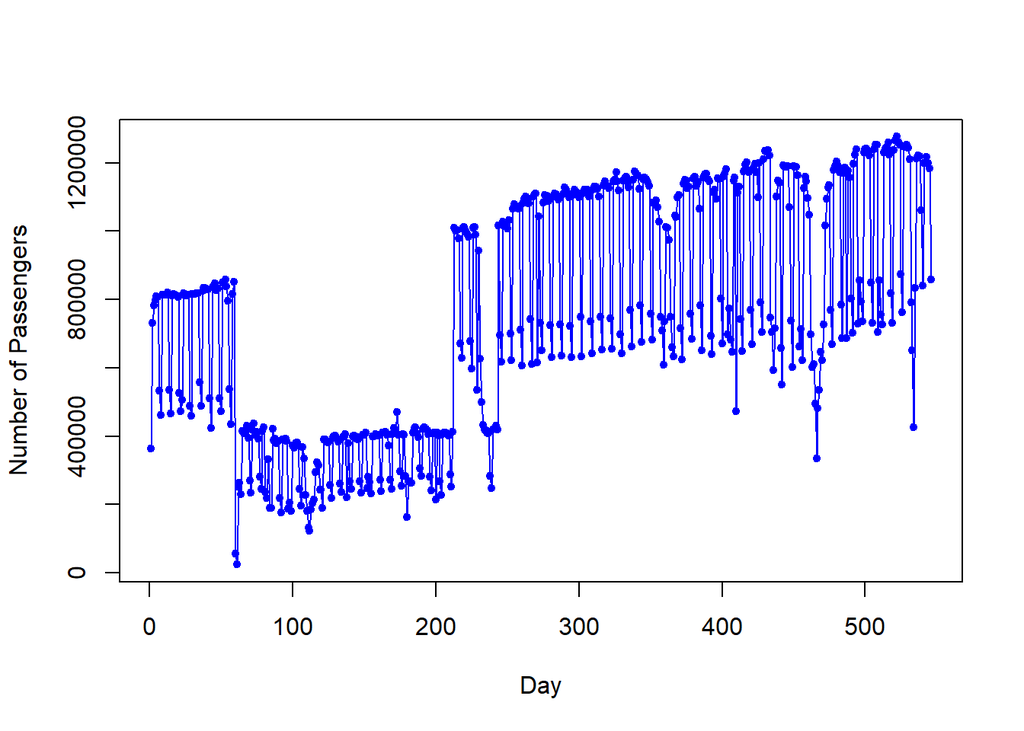

```r
ts.plot(data[,1], type="l", xlab = "Day", ylab="Number of Passengers", col="blue")
points(data[,1], pch = 20, col = "blue")
```

## Pembagian Data

```r
Yt <- data$jumlah_penumpang_transjakarta
Xt <- as.factor(data$PenyesuaianRute)

data <- as.data.frame(cbind(Yt, Xt))
```

```r
# Split Data
training <- data[1:477,]
testing <- data[478:546,]
```

```r
# Data Time Series
training.ts <- ts(training)
testing.ts <- ts(testing)
data.ts <- ts(data)
```

## Model Autoregressive

Peubah dependen dipengaruhi oleh peubah independen pada waktu sekarang, serta dipengaruhi juga oleh peubah dependen itu sendiri pada satu waktu yang lalu maka model tersebut disebut *autoregressive* (Gujarati 2004).

### Pemodelan

Pemodelan Autoregressive dilakukan menggunakan fungsi `dLagM::ardlDlm()` . Fungsi tersebut akan menerapkan *autoregressive* berordo $(p,q)$ dengan satu prediktor. Fungsi umum dari `ardlDlm()` adalah sebagai berikut.

```r
ardlDlm(formula = NULL , data = NULL , x = NULL , y = NULL , p = 1 , q = 1 ,
         remove = NULL )
```

Dengan $p$ adalah integer yang mewakili panjang *lag* yang terbatas dan $q$ adalah integer yang merepresentasikan ordo dari proses *autoregressive*.

### *Lag* Optimum

```r
modelardl <- ardlBoundOrders(data = data.frame(data), ic = "AIC",
                                  formula = Yt ~ Xt )
min_p=c()
for(i in 1:5){
  min_p[i]=min(modelardl$Stat.table[[i]])
}
q_opt=which(min_p==min(min_p, na.rm = TRUE))
p_opt=which(modelardl$Stat.table[[q_opt]] ==
              min(modelardl$Stat.table[[q_opt]], na.rm = TRUE))
data.frame("q_optimum" = q_opt, "p_optimum" = p_opt,
           "AIC"=modelardl$min.Stat)
```

```
##   q_optimum p_optimum      AIC
## 1         5        14 14007.38
```

Dari tabel di atas, dapat terlihat bahwa nilai AIC terendah didapat ketika $p=14$ dan $q=5$, yaitu sebesar `14007.38`. Artinya, model autoregressive optimum didapat ketika $p=14$ dan $q=5$.

Selanjutnya dapat dilakukan pemodelan dengan nilai $p$ dan $q$ optimum.

### Pemodelan dengan *Lag* Optimum

```r
modelardl <- ardlDlm(formula = Yt ~ Xt, data = training, p = 14, q = 5)
summary(modelardl)
```

```
##
## Time series regression with "ts" data:
## Start = 15, End = 477
##
## Call:
## dynlm(formula = as.formula(model.text), data = data)
##
## Residuals:
##     Min      1Q  Median      3Q     Max
## -482505  -98809   18070  106630  535656
##
## Coefficients:
##               Estimate Std. Error t value Pr(>|t|)
## (Intercept)  6.223e+05  8.902e+04   6.991 1.01e-11 ***
## Xt.t        -6.849e+05  1.207e+05  -5.677 2.49e-08 ***
## Xt.1         4.240e+05  1.723e+05   2.461 0.014229 *
## Xt.2        -7.546e+04  1.734e+05  -0.435 0.663563
## Xt.3         6.435e+04  1.734e+05   0.371 0.710794
## Xt.4         9.660e+04  1.734e+05   0.557 0.577856
## Xt.5         5.754e+04  1.725e+05   0.333 0.738922
## Xt.6        -2.171e+05  1.697e+05  -1.279 0.201581
## Xt.7         1.342e+05  1.700e+05   0.789 0.430314
## Xt.8        -6.105e+04  1.701e+05  -0.359 0.719744
## Xt.9         1.827e+04  1.701e+05   0.107 0.914526
## Xt.10       -7.352e+04  1.701e+05  -0.432 0.665765
## Xt.11        1.849e+05  1.697e+05   1.090 0.276478
## Xt.12        2.244e+04  1.697e+05   0.132 0.894858
## Xt.13       -2.345e+05  1.697e+05  -1.382 0.167586
## Xt.14        1.032e+05  1.204e+05   0.857 0.392032
## Yt.1         7.038e-01  4.720e-02  14.911  < 2e-16 ***
## Yt.2        -3.322e-01  5.760e-02  -5.768 1.51e-08 ***
## Yt.3         2.217e-01  5.894e-02   3.761 0.000192 ***
## Yt.4        -1.055e-01  5.776e-02  -1.826 0.068543 .
## Yt.5         8.843e-02  4.745e-02   1.864 0.063051 .
## ---
## Signif. codes:  0 '***' 0.001 '**' 0.01 '*' 0.05 '.' 0.1 ' ' 1
##
## Residual standard error: 169500 on 442 degrees of freedom
## Multiple R-squared:  0.7632, Adjusted R-squared:  0.7524
## F-statistic: 71.21 on 20 and 442 DF,  p-value: < 2.2e-16
```

```r
AIC(modelardl)
```

```
## [1] 12485.82
```

```r
BIC(modelardl)
```

```
## [1] 12576.85
```

Dari hasil tersebut, didapat bahwa peubah $x_t$, $x_{t-1}$, $y_{t-1}$, $y_{t-2}$, dan $y_{t-3}$ memiliki nilai $P-Value<0.05$. Hal ini menunjukkan bahwa peubah $x_t$, $x_{t-1}$, $y_{t-1}$, $y_{t-2}$, dan $y_{t-3}$ berpengaruh signifikan terhadap $y_t$ sementara yang lainnya tidak berpengaruh signifikan terhadap $y_t$. Artinya, jumlah penumpang transjakarta satu periode sebelumnya, dua periode sebelumnya, tiga periode sebelumnya, dan penyesuaian rute pada periode sekarang dan satu periode sebelumnya berpengaruh signifikan terhadap jumlah penumpang periode sekarang. Adapun model keseluruhannya adalah sebagai berikut.

$$\hat{Y_t}=(6.223e+0)+(-6.849e+05)X_t-...+(8.843e-02)Y_{t-5}$$

## Pemodelan ARDL dengan Library `dynlm`

Pemodelan regresi dengan peubah *lag* tidak hanya dapat dilakukan dengan fungsi pada *packages* `dLagM` , tetapi terdapat *packages* `dynlm` yang dapat digunakan. Fungsi `dynlm` secara umum adalah sebagai berikut.

```r
dynlm(formula, data, subset, weights, na.action, method = "qr",
  model = TRUE, x = FALSE, y = FALSE, qr = TRUE, singular.ok = TRUE,
  contrasts = NULL, offset, start = NULL, end = NULL, ...)
```

Untuk menentukan `formula` model yang akan digunakan, tersedia fungsi tambahan yang memungkinkan spesifikasi dinamika (melalui `d()` dan `L()`) atau pola linier/siklus dengan mudah (melalui `trend()`, `season()`, dan `harmon()`). Semua fungsi formula baru mengharuskan argumennya berupa objek deret waktu (yaitu, `"ts"` atau `"zoo"`).

### Pemodelan

```r
#sama dengan model ardl p=14 q=5
cons_lm1 <- dynlm(Yt ~ Xt+L(Xt)+L(Xt,2)+L(Xt,3)+L(Xt,4)+L(Xt,5)+L(Xt,6)+L(Xt,7)+L(Xt,8)+L(Xt,9)+L(Xt,10)+L(Xt,11)+L(Xt,12)+L(Xt,13)+L(Xt,14)+L(Yt)+L(Yt,2)+L(Yt,3)+L(Yt,4)+L(Yt,5),data = training.ts)
cons_lm1
```

```
##
## Time series regression with "ts" data:
## Start = 15, End = 477
##
## Call:
## dynlm(formula = Yt ~ Xt + L(Xt) + L(Xt, 2) + L(Xt, 3) + L(Xt,
##     4) + L(Xt, 5) + L(Xt, 6) + L(Xt, 7) + L(Xt, 8) + L(Xt, 9) +
##     L(Xt, 10) + L(Xt, 11) + L(Xt, 12) + L(Xt, 13) + L(Xt, 14) +
##     L(Yt) + L(Yt, 2) + L(Yt, 3) + L(Yt, 4) + L(Yt, 5), data = training.ts)
##
## Coefficients:
## (Intercept)           Xt        L(Xt)     L(Xt, 2)     L(Xt, 3)     L(Xt, 4)
##   6.223e+05   -6.849e+05    4.240e+05   -7.546e+04    6.435e+04    9.660e+04
##    L(Xt, 5)     L(Xt, 6)     L(Xt, 7)     L(Xt, 8)     L(Xt, 9)    L(Xt, 10)
##   5.754e+04   -2.171e+05    1.342e+05   -6.105e+04    1.827e+04   -7.352e+04
##   L(Xt, 11)    L(Xt, 12)    L(Xt, 13)    L(Xt, 14)        L(Yt)     L(Yt, 2)
##   1.849e+05    2.244e+04   -2.345e+05    1.032e+05    7.038e-01   -3.322e-01
##    L(Yt, 3)     L(Yt, 4)     L(Yt, 5)
##   2.217e-01   -1.055e-01    8.843e-02
```

```r
summary(cons_lm1)
```

```
##
## Time series regression with "ts" data:
## Start = 15, End = 477
##
## Call:
## dynlm(formula = Yt ~ Xt + L(Xt) + L(Xt, 2) + L(Xt, 3) + L(Xt,
##     4) + L(Xt, 5) + L(Xt, 6) + L(Xt, 7) + L(Xt, 8) + L(Xt, 9) +
##     L(Xt, 10) + L(Xt, 11) + L(Xt, 12) + L(Xt, 13) + L(Xt, 14) +
##     L(Yt) + L(Yt, 2) + L(Yt, 3) + L(Yt, 4) + L(Yt, 5), data = training.ts)
##
## Residuals:
##     Min      1Q  Median      3Q     Max
## -482505  -98809   18070  106630  535656
##
## Coefficients:
##               Estimate Std. Error t value Pr(>|t|)
## (Intercept)  6.223e+05  8.902e+04   6.991 1.01e-11 ***
## Xt          -6.849e+05  1.207e+05  -5.677 2.49e-08 ***
## L(Xt)        4.240e+05  1.723e+05   2.461 0.014229 *
## L(Xt, 2)    -7.546e+04  1.734e+05  -0.435 0.663563
## L(Xt, 3)     6.435e+04  1.734e+05   0.371 0.710794
## L(Xt, 4)     9.660e+04  1.734e+05   0.557 0.577856
## L(Xt, 5)     5.754e+04  1.725e+05   0.333 0.738922
## L(Xt, 6)    -2.171e+05  1.697e+05  -1.279 0.201581
## L(Xt, 7)     1.342e+05  1.700e+05   0.789 0.430314
## L(Xt, 8)    -6.105e+04  1.701e+05  -0.359 0.719744
## L(Xt, 9)     1.827e+04  1.701e+05   0.107 0.914526
## L(Xt, 10)   -7.352e+04  1.701e+05  -0.432 0.665765
## L(Xt, 11)    1.849e+05  1.697e+05   1.090 0.276478
## L(Xt, 12)    2.244e+04  1.697e+05   0.132 0.894858
## L(Xt, 13)   -2.345e+05  1.697e+05  -1.382 0.167586
## L(Xt, 14)    1.032e+05  1.204e+05   0.857 0.392032
## L(Yt)        7.038e-01  4.720e-02  14.911  < 2e-16 ***
## L(Yt, 2)    -3.322e-01  5.760e-02  -5.768 1.51e-08 ***
## L(Yt, 3)     2.217e-01  5.894e-02   3.761 0.000192 ***
## L(Yt, 4)    -1.055e-01  5.776e-02  -1.826 0.068543 .
## L(Yt, 5)     8.843e-02  4.745e-02   1.864 0.063051 .
## ---
## Signif. codes:  0 '***' 0.001 '**' 0.01 '*' 0.05 '.' 0.1 ' ' 1
##
## Residual standard error: 169500 on 442 degrees of freedom
## Multiple R-squared:  0.7632, Adjusted R-squared:  0.7524
## F-statistic: 71.21 on 20 and 442 DF,  p-value: < 2.2e-16
```

### SSE

```r
deviance(cons_lm1)
```

```
## [1] 1.26926e+13
```

### Uji Diagnostik

#### Autokorelasi

```r
dwtest(cons_lm1)
```

```
##
##  Durbin-Watson test
##
## data:  cons_lm1
## DW = 2.0852, p-value = 0.794
## alternative hypothesis: true autocorrelation is greater than 0
```

Berdasarkan hasil uji diagnostik model yaitu autokorelasi diperoleh $P-Value>0.05$ untuk model ARDL. Artinya, *tidak terjadi autokorelasi* pada model ardl.

#### Heterogenitas

```r
Box.test((residuals(cons_lm1))^2, type = "Ljung")
```

```
##
##  Box-Ljung test
##
## data:  (residuals(cons_lm1))^2
## X-squared = 6.0445, df = 1, p-value = 0.01395
```

Berdasarkan hasil uji diagnostik model yaitu heterogenitas diperoleh $P-Value<0.05$. Artinya, *terjadi heterogenitas* pada model ardl.

#### Normalitas

```r
shapiro.test(residuals(cons_lm1))
```

```
##
##  Shapiro-Wilk normality test
##
## data:  residuals(cons_lm1)
## W = 0.98715, p-value = 0.0004187
```

```r
ks.test(residuals(cons_lm1), "pnorm", mean=mean(residuals(cons_lm1)), sd=sd(residuals(cons_lm1)))
```

```
##
##  Asymptotic one-sample Kolmogorov-Smirnov test
##
## data:  residuals(cons_lm1)
## D = 0.066524, p-value = 0.03321
## alternative hypothesis: two-sided
```

```r
nortest::ad.test(residuals(cons_lm1))
```

```
##
##  Anderson-Darling normality test
##
## data:  residuals(cons_lm1)
## A = 2.4683, p-value = 3.03e-06
```

```r
tseries::jarque.bera.test(residuals(cons_lm1))
```

```
##
##  Jarque Bera Test
##
## data:  residuals(cons_lm1)
## X-squared = 2.593, df = 2, p-value = 0.2735
```

Berdasarkan hasil uji diagnostik model yaitu normalitas dengan menggunakan uji shapiro-wilk, kolmogorov smirnov, dan anderson darling diperoleh $P-Value<0.05$ untuk ardl. Artinya, *normalitas tidak terpenuhi* pada model ardl. Namun, berdasarkan hasil uji diagnostik model yaitu normalitas dengan menggunakan uji jarque bera diperoleh $P-Value>0.05$ untuk model ardl. Artinya, *normalitas terpenuhi* pada model ardl.

#### Nilai Harapan Galat

```r
t.test(residuals(cons_lm1), mu = 0, conf.level = 0.95)
```

```
##
##  One Sample t-test
##
## data:  residuals(cons_lm1)
## t = 9.1025e-16, df = 462, p-value = 1
## alternative hypothesis: true mean is not equal to 0
## 95 percent confidence interval:
##  -15137.39  15137.39
## sample estimates:
##    mean of x
## 7.011691e-12
```

Berdasarkan hasil uji diagnostik model yaitu nilai harapan galat sama dengan 0 diperoleh $P-Value > 0.05$ artinya *nilai harapan galat = 0 terpenuhi*.

Namun, akibat dari diagnostik model yaitu ragam homogen tidak terpenuhi maka peramalan belum dapat dilakukan. Dengan demikian perlu dilakukan penanganan terlebih dahulu agar mendapatkan model terbaik yang memenuhi diagnostik model.

### CCF

Plot ccf digunaka untuk melakukan pengecekan terhadap lag. Kemudian lag signifikan atau melebihi batas saja yang akan dimasukkan ke dalam model.

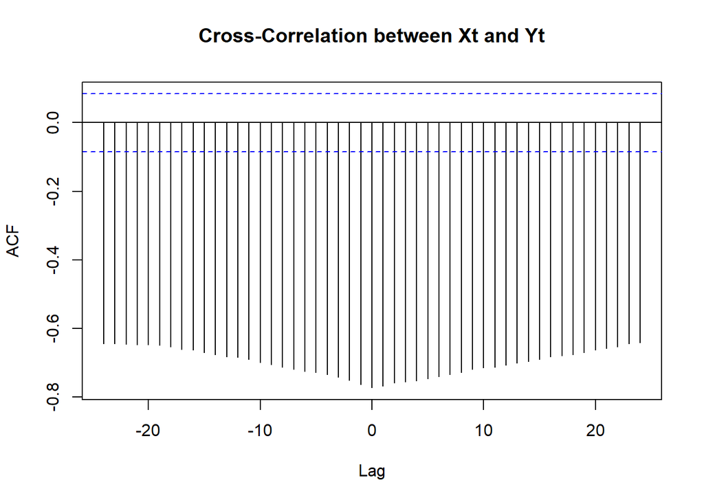

```r
ccf(data$Xt, data$Yt, main = "Cross-Correlation between Xt and Yt")
```

Berdasarkan plot ccf di atas diperoleh bahwa lag 0 hingga 24 signifikan sehingga plot ccf tidak membantu penanganan kasus ini.

### Pemodelan dengan *Lag* Signifikan

Penanganan selanjutnya adalah dengan mencoba memasukkan satu per satu lag signifikan dan berhenti ketika lag tersebut tidak signifikan dimulai dari lag Xt dan dilanjutkan dengan lag Yt.

```r
#sama dengan model ardl p=1 q=3
cons_lm2 <- dynlm(Yt ~ Xt+L(Xt)+L(Yt)+L(Yt,2)+L(Yt,3),data = training.ts)
cons_lm2
```

```
##
## Time series regression with "ts" data:
## Start = 4, End = 477
##
## Call:
## dynlm(formula = Yt ~ Xt + L(Xt) + L(Yt) + L(Yt, 2) + L(Yt, 3),
##     data = training.ts)
##
## Coefficients:
## (Intercept)           Xt        L(Xt)        L(Yt)     L(Yt, 2)     L(Yt, 3)
##   6.459e+05   -6.818e+05    4.326e+05    6.944e-01   -2.984e-01    1.595e-01
```

```r
summary(cons_lm2)
```

```
##
## Time series regression with "ts" data:
## Start = 4, End = 477
##
## Call:
## dynlm(formula = Yt ~ Xt + L(Xt) + L(Yt) + L(Yt, 2) + L(Yt, 3),
##     data = training.ts)
##
## Residuals:
##     Min      1Q  Median      3Q     Max
## -489310  -98758   15243  101581  549100
##
## Coefficients:
##               Estimate Std. Error t value Pr(>|t|)
## (Intercept)  6.459e+05  7.381e+04   8.751  < 2e-16 ***
## Xt          -6.818e+05  1.198e+05  -5.690 2.24e-08 ***
## L(Xt)        4.326e+05  1.215e+05   3.559 0.000410 ***
## L(Yt)        6.944e-01  4.507e-02  15.408  < 2e-16 ***
## L(Yt, 2)    -2.984e-01  5.290e-02  -5.641 2.93e-08 ***
## L(Yt, 3)     1.595e-01  4.427e-02   3.603 0.000348 ***
## ---
## Signif. codes:  0 '***' 0.001 '**' 0.01 '*' 0.05 '.' 0.1 ' ' 1
##
## Residual standard error: 168400 on 468 degrees of freedom
## Multiple R-squared:  0.7532, Adjusted R-squared:  0.7505
## F-statistic: 285.6 on 5 and 468 DF,  p-value: < 2.2e-16
```

### SSE

```r
deviance(cons_lm2)
```

```
## [1] 1.327812e+13
```

### Uji Diagnostik

#### Autokorelasi

```r
dwtest(cons_lm2)
```

```
##
##  Durbin-Watson test
##
## data:  cons_lm2
## DW = 1.9843, p-value = 0.4015
## alternative hypothesis: true autocorrelation is greater than 0
```

Berdasarkan hasil uji diagnostik model yaitu autokorelasi diperoleh $P-Value>0.05$ untuk model ARDL. Artinya, *tidak terjadi autokorelasi* pada model ardl.

#### Heterogenitas

```r
Box.test((residuals(cons_lm2))^2, type = "Ljung")
```

```
##
##  Box-Ljung test
##
## data:  (residuals(cons_lm2))^2
## X-squared = 1.1013, df = 1, p-value = 0.294
```

Berdasarkan hasil uji diagnostik model yaitu heterogenitas diperoleh $P-Value>0.05$. Artinya, *tidak terjadi heterogenitas* pada model ardl.

#### Normalitas

```r
shapiro.test(residuals(cons_lm2))
```

```
##
##  Shapiro-Wilk normality test
##
## data:  residuals(cons_lm2)
## W = 0.98947, p-value = 0.001758
```

```r
ks.test(residuals(cons_lm2), "pnorm", mean=mean(residuals(cons_lm2)), sd=sd(residuals(cons_lm2)))
```

```
##
##  Asymptotic one-sample Kolmogorov-Smirnov test
##
## data:  residuals(cons_lm2)
## D = 0.050377, p-value = 0.1802
## alternative hypothesis: two-sided
```

```r
nortest::ad.test(residuals(cons_lm2))
```

```
##
##  Anderson-Darling normality test
##
## data:  residuals(cons_lm2)
## A = 1.9953, p-value = 4.356e-05
```

```r
tseries::jarque.bera.test(residuals(cons_lm2))
```

```
##
##  Jarque Bera Test
##
## data:  residuals(cons_lm2)
## X-squared = 0.94275, df = 2, p-value = 0.6241
```

Berdasarkan hasil uji diagnostik model yaitu normalitas dengan menggunakan uji shapiro-wilk dan anderson darling diperoleh $P-Value<0.05$ untuk ardl. Artinya, *normalitas tidak terpenuhi* pada model ardl. Namun, berdasarkan hasil uji diagnostik model yaitu normalitas dengan menggunakan uji kolmogorov-smirnov dan jarque bera diperoleh $P-Value>0.05$ untuk model ardl. Artinya, *normalitas terpenuhi* pada model ardl.

#### Nilai Harapan Galat

```r
t.test(residuals(cons_lm2), mu = 0, conf.level = 0.95)
```

```
##
##  One Sample t-test
##
## data:  residuals(cons_lm2)
## t = 1.3821e-15, df = 473, p-value = 1
## alternative hypothesis: true mean is not equal to 0
## 95 percent confidence interval:
##  -15122  15122
## sample estimates:
##    mean of x
## 1.063588e-11
```

Berdasarkan hasil uji diagnostik model yaitu nilai harapan galat sama dengan 0 diperoleh $P-Value > 0.05$ artinya *nilai harapan galat = 0 terpenuhi*.

### Pemodelan untuk Peramalan

```r
modelardl2 <- ardlDlm(formula = Yt ~ Xt, data = training, p = 1, q = 3)
summary(modelardl2)
```

```
##
## Time series regression with "ts" data:
## Start = 4, End = 477
##
## Call:
## dynlm(formula = as.formula(model.text), data = data)
##
## Residuals:
##     Min      1Q  Median      3Q     Max
## -489310  -98758   15243  101581  549100
##
## Coefficients:
##               Estimate Std. Error t value Pr(>|t|)
## (Intercept)  6.459e+05  7.381e+04   8.751  < 2e-16 ***
## Xt.t        -6.818e+05  1.198e+05  -5.690 2.24e-08 ***
## Xt.1         4.326e+05  1.215e+05   3.559 0.000410 ***
## Yt.1         6.944e-01  4.507e-02  15.408  < 2e-16 ***
## Yt.2        -2.984e-01  5.290e-02  -5.641 2.93e-08 ***
## Yt.3         1.595e-01  4.427e-02   3.603 0.000348 ***
## ---
## Signif. codes:  0 '***' 0.001 '**' 0.01 '*' 0.05 '.' 0.1 ' ' 1
##
## Residual standard error: 168400 on 468 degrees of freedom
## Multiple R-squared:  0.7532, Adjusted R-squared:  0.7505
## F-statistic: 285.6 on 5 and 468 DF,  p-value: < 2.2e-16
```

```r
AIC(modelardl2)
```

```
## [1] 12761.67
```

```r
BIC(modelardl2)
```

```
## [1] 12790.79
```

### Peramalan

```r
foreardl <- forecast(model = modelardl2, x = training$Xt, h = 69)
foreardl
```

```
## $forecasts
##  [1] 812143.6 884038.3 874863.7 870018.1 880859.1 888369.7 889577.6 889904.8
##  [9] 890969.6 891804.1 892118.1 892257.0 892392.9 892495.9 892549.0 892576.9
## [17] 892596.8 892610.8 892619.0 892623.7 892626.7 892628.8 892630.0 892630.8
## [25] 892631.2 892631.5 892631.7 892631.8 892631.9 892632.0 892632.0 892632.0
## [33] 892632.0 892632.0 892632.0 892632.0 892632.0 892632.0 892632.0 892632.0
## [41] 892632.0 892632.0 892632.0 892632.0 892632.0 892632.0 892632.0 892632.0
## [49] 892632.0 892632.0 892632.0 892632.0 892632.0 892632.0 892632.0 892632.0
## [57] 892632.0 892632.0 892632.0 210869.6 170014.0 345065.4 370064.5 328676.0
## [65] 320399.0 330988.4 334209.5 331966.4 331136.8
##
## $call
## forecast.ardlDlm(model = modelardl2, x = training$Xt, h = 69)
##
## attr(,"class")
## [1] "forecast.ardlDlm" "dLagM"
```

### Akurasi

```r
# Akurasi Data Testing
mapeardl <- MAPE(foreardl$forecasts, testing$Yt)
mapeardl
```

```
## [1] 0.3178813
```

```r
# Akurasi Data Training
GoF(modelardl)
```

```
##             n    MAE         MPE      MAPE     sMAPE     MASE         MSE
## modelardl 463 126952 -0.06768397 0.2166388 0.1974668 1.053469 27413818385
##               MRAE    GMRAE
## modelardl 13.23198 2.323283
```

### Fitted Values

```r
# 1. Syntax untuk fitted values pada data training
fitted_values_train <- fitted(modelardl2)
```

[output not shown]

[output cut: 68 more lines]

```r
fitted_values_train
```

```
## Time Series:
## Start = 4
## End = 477
## Frequency = 1
##   [1]  780445.49  834086.64  844445.36  843851.90  654751.37  687517.08
##   [7]  908441.30  792564.41  848762.00  849307.54  852264.55  654418.33
##  [13]  691688.30  906170.73  795741.36  847138.47  847538.25  844377.24
##  [19]  650905.31  696391.20  690435.79  889649.50  796895.71  847721.26
##  [25]  849378.89  621713.40  700459.53  904315.09  793295.78  849286.30
##  [31]  852346.20  851144.96  669626.74  700234.13  912821.92  806509.42
##  [37]  858457.27  858606.24  856529.99  636534.11  670260.21  932383.31
##  [43]  798681.45  866814.99  853023.63  862167.51  635145.67  705425.85
##  [49]  926652.19  807243.27  874821.14  858683.58  836216.96  666694.53
##  [55]  665075.78  919777.97  132055.46   62523.06  283485.17  323789.01
##  [61]  259815.72  268837.08  408405.62  343586.91  378070.03  388507.12
```

[output cut: 68 more lines]

```r
# 2. Forecast 28 hari ke depan setelah data testing (bukan data testing)
forecast_28 <- forecast(model = modelardl2, x = data$Xt, h = 14)
forecast_28
```

```
## $forecasts
##  [1] 812143.6 884038.3 874863.7 870018.1 880859.1 888369.7 889577.6 889904.8
##  [9] 890969.6 891804.1 892118.1 892257.0 892392.9 892495.9
##
## $call
## forecast.ardlDlm(model = modelardl2, x = data$Xt, h = 14)
##
## attr(,"class")
## [1] "forecast.ardlDlm" "dLagM"
```

### MAPE manual

```r
# 3. Menghitung MAPE untuk data training dan testing secara manual
# MAPE untuk Training
actual_train <- training$Yt
mape_train <- mean(abs((actual_train[1:474] - fitted_values_train) / actual_train[1:474])) * 100
mape_train
```

```
## [1] 33.92546
```

```r
# MAPE untuk Testing
actual_test <- testing$Yt
pred_test <- foreardl$forecasts  # Forecast hasil pada testing
mape_test <- mean(abs((actual_test - pred_test) / actual_test)) * 100
mape_test
```

```
## [1] 31.78813
```

### Plot

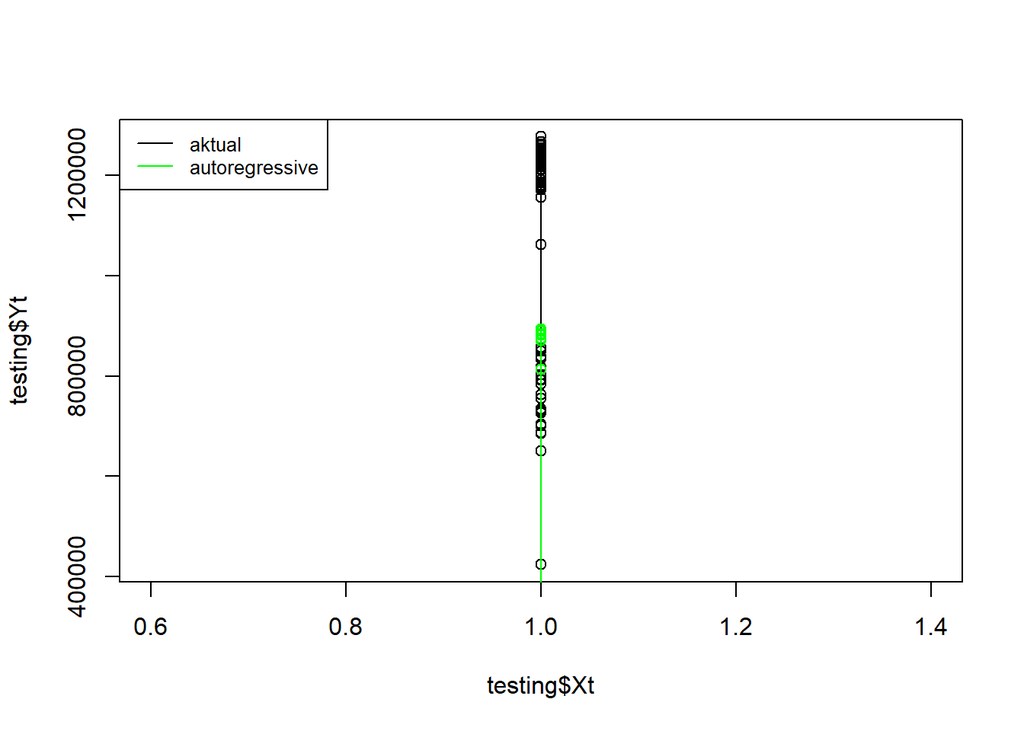

```r
par(mfrow=c(1,1))
plot(testing$Xt, testing$Yt, type="b", col="black")
points(testing$Xt, foreardl$forecasts,col="green")
lines(testing$Xt, foreardl$forecasts,col="green")
legend("topleft",c("aktual", "autoregressive"), lty=1, col=c("black","green"), cex=0.8)
```

### Multistep forecast

```r
# Initialize vectors to store forecasts and actuals
forecasts <- numeric(length(testing$Yt))
actuals <- testing$Yt

model2 <- ardlDlm(formula = Yt ~ Xt, data = training, p = 1, q = 3)
```

```r
# Iterative forecasting loop
for (i in 1:length(testing$Yt)) {
  # Define training data up to the i-th test point
  updated_training <- rbind(training, testing[1:i, ])

  # Fit the ARDL model to the updated training data
  model <- ardlDlm(formula = Yt ~ Xt, data = updated_training, p = 1, q = 3)

  # Forecast the next time step (i-th point in the test set)
  next_forecast <- forecast(model = model, x = testing$Xt[i], h = 1)$forecasts

  # Store the forecasted value
  forecasts[i] <- next_forecast
}
```

#### MAPE Multistep

```r
# Calculate MAPE for testing data
mape_testing <- MAPE(forecasts, actuals)
cat("MAPE for testing data:", mape_testing, "\n")
```

```
## MAPE for testing data: 0.1119063
```

```r
# Create a data frame for plotting
forecast_data <- data.frame(
  Date = 478:546,
  Actual = actuals,
  Forecast = forecasts
)
Forecast = forecasts
forecast_testing = forecasts
```

### Plot

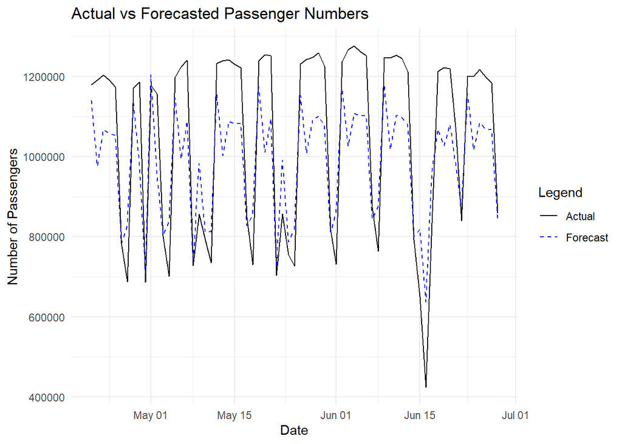

```r
# Inisialisasi tanggal dari 21 April 2024 hingga 30 Juni 2024
forecast_data$Date <- seq(from = as.Date("2024-04-21"), to = as.Date("2024-06-28"), by = "day")


# Plot actual vs. forecasted values dengan rentang tanggal yang disesuaikan
ggplot(forecast_data, aes(x = Date)) +
  geom_line(aes(y = Actual, color = "Actual"), size = 0.5) +
  geom_line(aes(y = Forecast, color = "Forecast"), size = 0.5, linetype = "dashed") +
  labs(
    title = "Actual vs Forecasted Passenger Numbers",
    x = "Date",
    y = "Number of Passengers"
  ) +
  scale_color_manual(
    name = "Legend",
    values = c("Actual" = "black", "Forecast" = "blue")
  ) +
  theme_minimal()
```

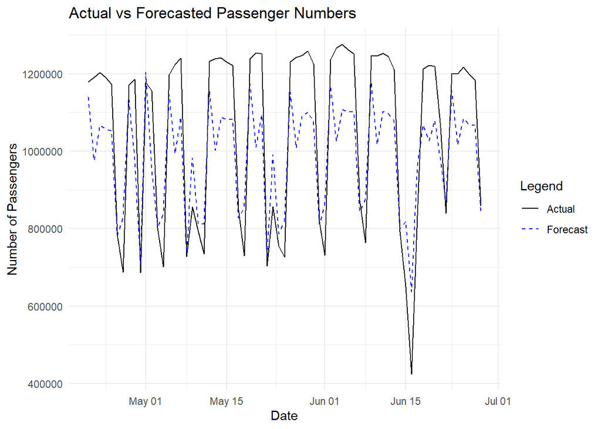

```r
Date <- seq(from = as.Date("2024-04-22"), to = as.Date("2024-06-29"), by = "day")
# Plot the actual vs. forecasted values
ggplot(forecast_data, aes(x = Date)) +
  geom_line(aes(y = Actual, color = "Actual"), size = 0.5) +
  geom_line(aes(y = Forecast, color = "Forecast"), size = 0.5, linetype = "dashed") +
  labs(
    title = "Actual vs Forecasted Passenger Numbers",
    x = "Date",
    y = "Number of Passengers"
  ) +
  scale_color_manual(
    name = "Legend",
    values = c("Actual" = "black", "Forecast" = "blue")
  ) +
  theme_minimal()
```

```r
model2.1 <-  dynlm(Yt ~ Xt+L(Xt)+L(Yt)+L(Yt,2)+L(Yt,3),data = training.ts)

dwtest(model2.1)
```

```
##
##  Durbin-Watson test
##
## data:  model2.1
## DW = 1.9843, p-value = 0.4015
## alternative hypothesis: true autocorrelation is greater than 0
```

```r
Box.test((residuals(model2.1))^2, type = "Ljung")
```

```
##
##  Box-Ljung test
##
## data:  (residuals(model2.1))^2
## X-squared = 1.1013, df = 1, p-value = 0.294
```

```r
tseries::jarque.bera.test(residuals(model2))
```

[output not shown]

[output cut: 107 more lines]

[output not shown]

```
##
##  Jarque Bera Test
##
## data:  residuals(model2)
## X-squared = 0.94275, df = 2, p-value = 0.6241
```

```r
ks.test(residuals(model2.1), "pnorm",mean=mean(residuals(model2.1)),sd=sd(residuals(model2.1)))
```

```
##
##  Asymptotic one-sample Kolmogorov-Smirnov test
##
## data:  residuals(model2.1)
## D = 0.050377, p-value = 0.1802
## alternative hypothesis: two-sided
```

```r
y1 <- training$Yt
y1 <- y1[-c(1:3)]
y1 <- matrix(nrow=474, ncol=1, y1)

y2 <- model2.1$fitted.values
y2 <- matrix(nrow=474, ncol=1, y2)

mape <- function(y1, y2) {
  mean(abs((y1 - y2) / y1)) * 100
}

mape(y1,y2) #mape testing
```

```
## [1] 21.69295
```

### Plot akhir

```r
library(ggplot2)
# Inisialisasi vector untuk menyimpan prediksi
forecasts <- numeric(14)  # Menyimpan prediksi 14 hari ke depan

# Salin data training dan testing sebagai data awal
updated_training <- training

# Multistep forecasting loop untuk 14 hari ke depan
for (i in 1:14) {
  # Fit the ARDL model ke data training yang diperbarui
  model <- ardlDlm(formula = Yt ~ Xt, data = updated_training, p = 1, q = 3)

  # Forecast untuk langkah ke-i
  # Ambil Xt dari data testing atau sebelumnya jika di luar data testing
  if (i <= nrow(testing)) {
    next_Xt <- testing$Xt[i]
  } else {
    next_Xt <- tail(updated_training$Xt, 1) # Gunakan Xt terakhir dari data yang diperbarui
  }

  # Prediksi nilai Yt berikutnya
  next_forecast <- forecast(model = model, x = next_Xt, h = 1)$forecasts

  # Simpan hasil prediksi
  forecasts[i] <- next_forecast

  # Perbarui data training dengan prediksi baru
  new_data <- data.frame(Yt = next_forecast, Xt = next_Xt)
  updated_training <- rbind(updated_training, new_data)
}

# Hasil prediksi
forecasts
```

```
##  [1] 812143.6 884038.3 874863.7 870018.1 880859.1 888369.7 889577.6 889904.8
##  [9] 890969.6 891804.1 892118.1 892257.0 892392.9 892495.9
```

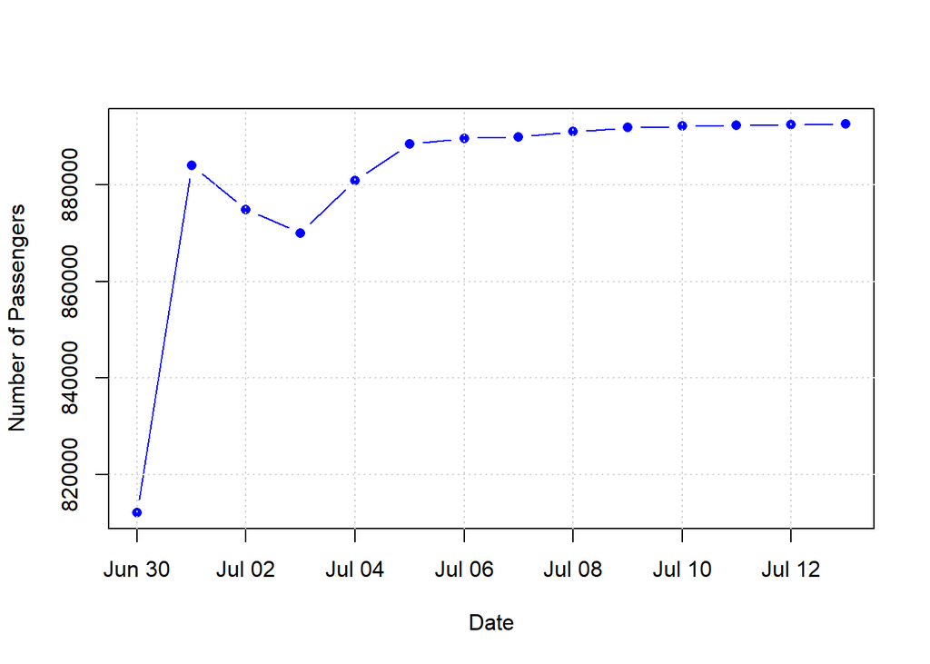

```r
# Buat vektor hari untuk sumbu X
days <- seq(from = as.Date("2024-06-30"), to = as.Date("2024-07-13"), by = "day")

# Buat plot sederhana
plot(
  x = days,
  y = forecasts,
  type = "b",  # Menggunakan garis dan titik
  col = "blue",  # Warna garis biru
  pch = 16,  # Bentuk titik bulat
  xlab = "Date",
  ylab = "Number of Passengers"
)

# Tambahkan grid agar lebih mudah dibaca
grid()
```

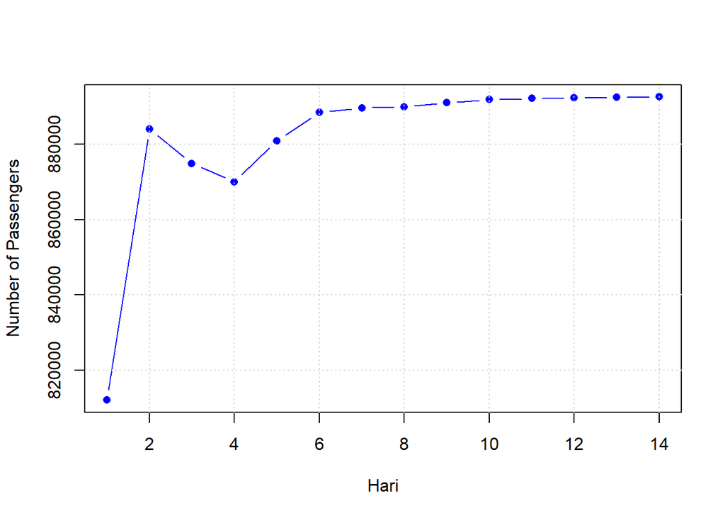

```r
# Initialize a vector to store forecasts
forecasts <- numeric(14)

# Gunakan data training awal
updated_data <- training

# Iteratif forecast untuk 14 hari ke depan
for (i in 1:14) {
  # Fit ARDL model ke data yang telah diperbarui
  model <- ardlDlm(formula = Yt ~ Xt, data = updated_data, p = 1, q = 3)

  # Forecast untuk hari berikutnya
  next_forecast <- forecast(model = model, x = tail(updated_data$Xt, 1), h = 1)$forecasts

  # Simpan hasil forecast
  forecasts[i] <- next_forecast

  # Update data dengan forecast sebagai nilai terbaru
  new_row <- data.frame(Yt = next_forecast, Xt = tail(updated_data$Xt, 1)) # Xt dapat disesuaikan sesuai skenario
  updated_data <- rbind(updated_data, new_row)
}

# Buat vektor hari untuk plot
days <- 1:14

# Plot hasil forecast
plot(
  x = days,
  y = forecasts,
  type = "b",  # Menggunakan garis dan titik
  col = "blue",  # Warna garis biru
  pch = 16,  # Bentuk titik bulat
  xlab = "Hari",
  ylab = "Number of Passengers",
)

# Tambahkan grid agar lebih mudah dibaca
grid()
```

```r
Date =seq(from = as.Date("2023-01-01"), to = as.Date("2024-07-13"), by = "day")
length(Date)
```

```
## [1] 560
```

```r
Forecast = c(data$Yt,  forecasts)
length(Forecast)
```

```
## [1] 560
```

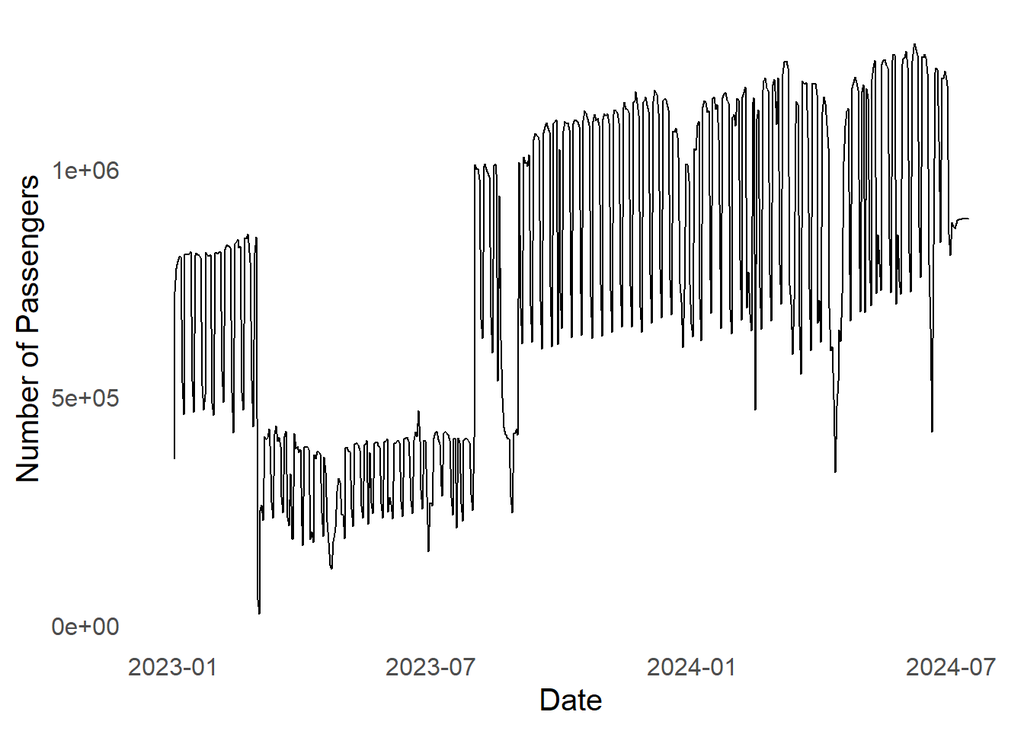

```r
# Extend the data frame
combined_data <- data.frame(Date, Forecast
)

ggplot(combined_data, aes(x = Date)) +
  geom_line(aes(y = Forecast), color = "black", size = 0.5) + # Garis prediksi hitam
  labs(
    x = "Date",
    y = "Number of Passengers"
  ) +
  theme_minimal(base_size = 15) + # Tema minimalis yang mirip
  theme(
    plot.title = element_text(hjust = 0.5), # Judul tengah dan tebal
    panel.grid.major = element_blank(), # Menghapus grid utama
    panel.grid.minor = element_blank()  # Menghapus grid minor
  )
```

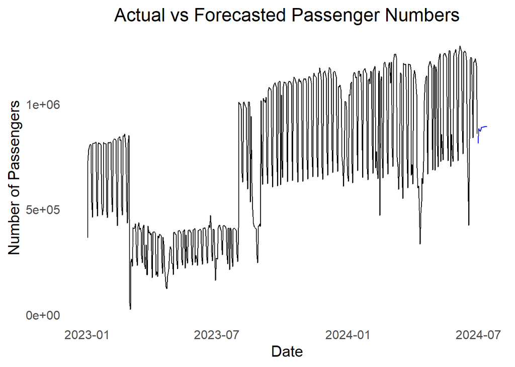

```r
# Extend the data frame
combined_data <- data.frame(
  Date = Date,
  Forecast = Forecast
)

# Panjang data aktual
actual_length <- length(data$Yt)

# Plot data aktual dan prediksi dengan warna berbeda
ggplot() +
  # Garis data aktual (hitam)
  geom_line(data = combined_data[1:actual_length, ], aes(x = Date, y = Forecast), color = "black", size = 0.5) +
  # Garis data prediksi (biru)
  geom_line(data = combined_data[(actual_length + 1):nrow(combined_data), ], aes(x = Date, y = Forecast), color = "blue", size = 0.5) +
  labs(
    x = "Date",
    y = "Number of Passengers",
    title = "Actual vs Forecasted Passenger Numbers"
  ) +
  theme_minimal(base_size = 15) +
  theme(
    plot.title = element_text(hjust = 0.5), # Judul tengah
    panel.grid.major = element_blank(), # Menghapus grid utama
    panel.grid.minor = element_blank()  # Menghapus grid minor
  )
```

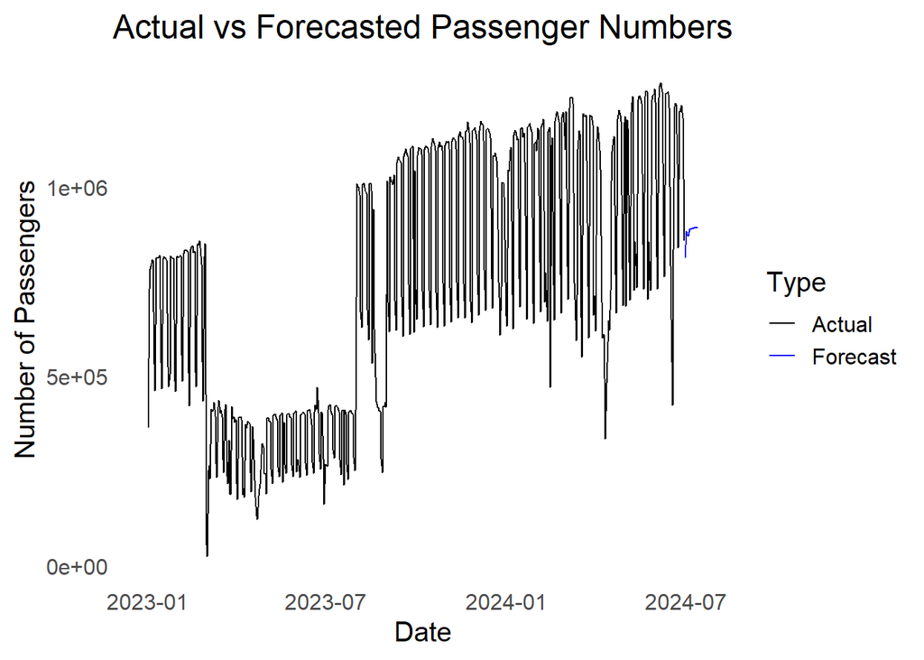

```r
# Extend the data frame dengan label untuk Actual dan Forecast
combined_data <- data.frame(
  Date = Date,
  Value = Forecast,
  Type = c(rep("Actual", length(data$Yt)), rep("Forecast", length(forecasts)))
)

# Plot gabungan
ggplot(combined_data, aes(x = Date, y = Value, color = Type)) +
  geom_line(size = 0.5) + # Garis untuk masing-masing tipe
  labs(
    x = "Date",
    y = "Number of Passengers",
    title = "Actual vs Forecasted Passenger Numbers"
  ) +
  scale_color_manual(
    values = c("Actual" = "black", "Forecast" = "blue") # Hitam untuk Actual, Biru untuk Forecast
  ) +
  theme_minimal(base_size = 15) +
  theme(
    plot.title = element_text(hjust = 0.5), # Judul tengah
    panel.grid.major = element_blank(), # Menghapus grid utama
    panel.grid.minor = element_blank()  # Menghapus grid minor
  )
```

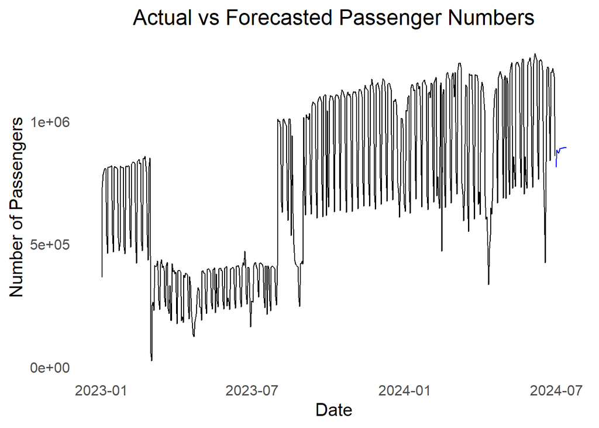

```r
# Panjang data aktual
actual_length <- length(data$Yt)

# Extend data frame untuk kompatibilitas plot
combined_data <- data.frame(
  Date = Date,
  Value = Forecast
)

# Plot data aktual (hitam) dan timpa dengan prediksi (biru)
ggplot(combined_data, aes(x = Date, y = Value)) +
  # Garis data aktual (hitam)
  geom_line(data = combined_data[1:actual_length, ], aes(x = Date, y = Value), color = "black", size = 0.5) +
  # Garis data prediksi (biru) menimpa garis hitam
  geom_line(data = combined_data[(actual_length + 1):nrow(combined_data), ], aes(x = Date, y = Value), color = "blue", size = 0.5) +
  labs(
    x = "Date",
    y = "Number of Passengers",
    title = "Actual vs Forecasted Passenger Numbers"
  ) +
  theme_minimal(base_size = 15) +
  theme(
    plot.title = element_text(hjust = 0.5), # Judul tengah
    panel.grid.major = element_blank(), # Menghapus grid utama
    panel.grid.minor = element_blank()  # Menghapus grid minor
  )
```

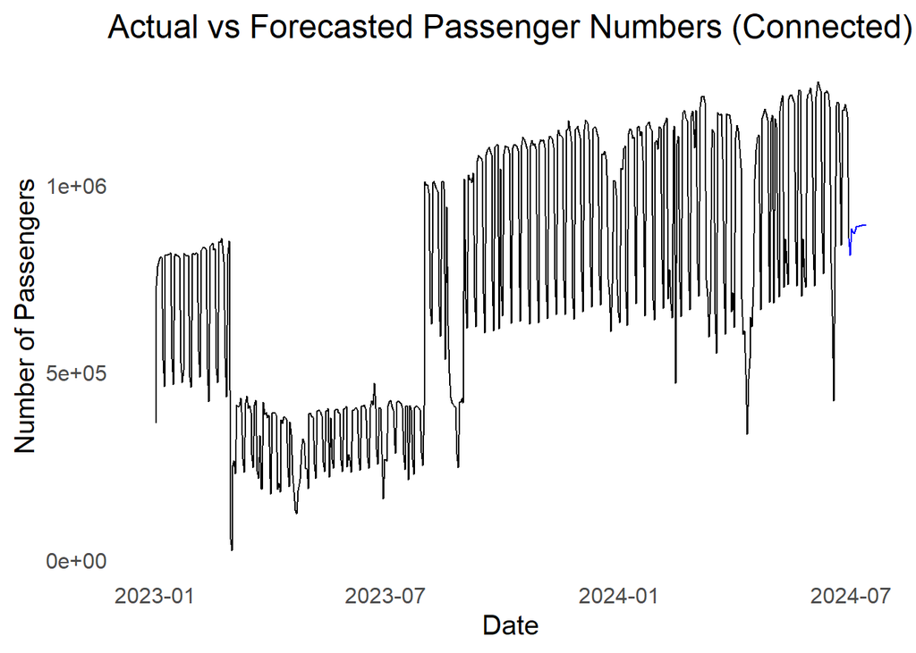

```r
# Extend data frame dengan prediksi dan actual yang terhubung
combined_data <- data.frame(
  Date = Date,
  Value = Forecast,
  Type = c(rep("Actual", length(data$Yt)), rep("Forecast", length(forecasts)))
)

# Gabungkan data terakhir dari aktual ke prediksi
connection_point <- data.frame(
  Date = Date[length(data$Yt)],
  Value = Forecast[length(data$Yt)],
  Type = "Forecast"
)

# Tambahkan connection_point ke data prediksi
connected_data <- rbind(combined_data, connection_point)

# Plot data
ggplot() +
  # Garis data aktual (hitam)
  geom_line(data = combined_data[combined_data$Type == "Actual", ],
            aes(x = Date, y = Value), color = "black", size = 0.5) +
  # Garis data prediksi (biru), termasuk connection_point
  geom_line(data = connected_data[connected_data$Type == "Forecast", ],
            aes(x = Date, y = Value), color = "blue", size = 0.5) +
  labs(
    x = "Date",
    y = "Number of Passengers",
    title = "Actual vs Forecasted Passenger Numbers (Connected)"
  ) +
  theme_minimal(base_size = 15) +
  theme(
    plot.title = element_text(hjust = 0.5), # Judul tengah
    panel.grid.major = element_blank(), # Menghapus grid utama
    panel.grid.minor = element_blank()  # Menghapus grid minor
  )
```

[figure not shown]

```r
library(ggplot2)

# Konversi kolom Date menjadi tipe Date
combined_data$Date <- as.Date(combined_data$Date)
connected_data$Date <- as.Date(connected_data$Date)

# Plot data dengan sumbu x diformat
ggplot() +
  # Garis data aktual (hitam)
  geom_line(data = combined_data[combined_data$Type == "Actual", ],
            aes(x = Date, y = Value), color = "black", size = 0.5) +
  # Garis data prediksi (biru), termasuk connection_point
  geom_line(data = connected_data[connected_data$Type == "Forecast", ],
            aes(x = Date, y = Value), color = "blue", size = 0.5) +
  labs(
    x = "Date",
    y = "Number of Passengers",
    title = "Actual vs Forecasted Passenger Numbers (Connected)"
  ) +
  scale_x_date(
    date_labels = "%b %Y", # Format label sumbu x
    date_breaks = "1 month" # Jarak antar label
  ) +
  theme_minimal(base_size = 15) +
  theme(
    plot.title = element_text(hjust = 0.5), # Judul tengah
    panel.grid.major = element_blank(), # Menghapus grid utama
    panel.grid.minor = element_blank()  # Menghapus grid minor
  )
```